# Анализ бизнес-показателей на основе построения сводных таблиц

Студент: Гулевская Владислава  
Группа: ХЕБО-04-22

## Раздел 1: Постановка задачи и исходные данные

Компания управляет онлайн-маркетплейсом товаров массового спроса. Задача данной работы провести анализ бизнес-показателей маркетплейса на основе построения сводных таблиц и определить:

- какие пользовательские сегменты приносят наибольшую выручку;
- как расходы клиентов распределяются по товарным категориям;
- какие маркетинговые каналы наиболее эффективны;
- как меняются показатели в зависимости от демографии клиентов.

Основной инструмент анализа - сводные таблицы, построенные с помощью функций: `groupby().agg()` и `pivot_table()` библиотеки Pandas. Каждый вывод в работе получен из сводной таблицы.

Используются три независимых датасета:

- Датасет 1 - `olist_customers_dataset.csv` - клиентская база бразильского маркетплейса Olist (99 441 запись)
- Датасет 2 - `Test.csv` - демографическая сегментация клиентов (2 627 записей)
- Датасет 3 - `marketing_campaign.csv` - расходы клиентов по категориям и данные о маркетинговых кампаниях (2 240 записей)

```python
import pandas as pd
import numpy as np
import matplotlib.pyplot as plt
import warnings
warnings.filterwarnings('ignore')

pd.set_option('display.float_format', '{:.2f}'.format)
pd.set_option('display.max_columns', 20)

print('Библиотеки загружены')
```

```
Библиотеки загружены
```

```python
import pandas as pd
from google.colab import files

uploaded = files.upload()

olist = pd.read_csv('olist_customers_dataset.csv')
segmentation = pd.read_csv('Test.csv')
marketing = pd.read_csv('marketing_campaign.csv', sep=';')

print('Датасеты загружены')
```

Upload widget is only available when the cell has been executed in the current browser session. Please rerun this cell to enable.

```
Saving marketing_campaign.csv to marketing_campaign (1).csv
Saving olist_customers_dataset.csv to olist_customers_dataset (1).csv
Saving Test.csv to Test (1).csv
Датасеты загружены
```

Изучим структуру и содержимое каждого датасета.

```python
print(f'Размер: {olist.shape[0]} строк, {olist.shape[1]} столбцов')
olist.head()
```

```
Размер: 99441 строк, 5 столбцов
```

|  | customer_id | customer_unique_id | customer_zip_code_prefix | customer_city | customer_state |
| --- | --- | --- | --- | --- | --- |
| 0 | 06b8999e2fba1a1fbc88172c00ba8bc7 | 861eff4711a542e4b93843c6dd7febb0 | 14409 | franca | SP |
| 1 | 18955e83d337fd6b2def6b18a428ac77 | 290c77bc529b7ac935b93aa66c333dc3 | 9790 | sao bernardo do campo | SP |
| 2 | 4e7b3e00288586ebd08712fdd0374a03 | 060e732b5b29e8181a18229c7b0b2b5e | 1151 | sao paulo | SP |
| 3 | b2b6027bc5c5109e529d4dc6358b12c3 | 259dac757896d24d7702b9acbbff3f3c | 8775 | mogi das cruzes | SP |
| 4 | 4f2d8ab171c80ec8364f7c12e35b23ad | 345ecd01c38d18a9036ed96c73b8d066 | 13056 | campinas | SP |

```python
olist.info()
print()
print('Пропуски:')
print(olist.isnull().sum())
print()
print('Уникальных клиентов:', olist['customer_unique_id'].nunique())
print('Уникальных штатов:', olist['customer_state'].nunique())
print('Уникальных городов:', olist['customer_city'].nunique())
```

```
<class 'pandas.core.frame.DataFrame'>
RangeIndex: 99441 entries, 0 to 99440
Data columns (total 5 columns):
 #   Column                    Non-Null Count  Dtype
---  ------                    --------------  -----
 0   customer_id               99441 non-null  object
 1   customer_unique_id        99441 non-null  object
 2   customer_zip_code_prefix  99441 non-null  int64
 3   customer_city             99441 non-null  object
 4   customer_state            99441 non-null  object
dtypes: int64(1), object(4)
memory usage: 3.8+ MB

Пропуски:
customer_id                 0
customer_unique_id          0
customer_zip_code_prefix    0
customer_city               0
customer_state              0
dtype: int64

Уникальных клиентов: 96096
Уникальных штатов: 27
Уникальных городов: 4119
```

```python
print(f'Размер: {segmentation.shape[0]} строк, {segmentation.shape[1]} столбцов')
segmentation.head()
```

```
Размер: 2627 строк, 10 столбцов
```

|  | ID | Gender | Ever_Married | Age | Graduated | Profession | Work_Experience | Spending_Score | Family_Size | Var_1 |
| --- | --- | --- | --- | --- | --- | --- | --- | --- | --- | --- |
| 0 | 458989 | Female | Yes | 36 | Yes | Engineer | 0.00 | Low | 1.00 | Cat_6 |
| 1 | 458994 | Male | Yes | 37 | Yes | Healthcare | 8.00 | Average | 4.00 | Cat_6 |
| 2 | 458996 | Female | Yes | 69 | No | NaN | 0.00 | Low | 1.00 | Cat_6 |
| 3 | 459000 | Male | Yes | 59 | No | Executive | 11.00 | High | 2.00 | Cat_6 |
| 4 | 459001 | Female | No | 19 | No | Marketing | NaN | Low | 4.00 | Cat_6 |

```python
segmentation.info()
print()
print('Пропуски:')
print(segmentation.isnull().sum())
```

```
<class 'pandas.core.frame.DataFrame'>
RangeIndex: 2627 entries, 0 to 2626
Data columns (total 10 columns):
 #   Column           Non-Null Count  Dtype
---  ------           --------------  -----
 0   ID               2627 non-null   int64
 1   Gender           2627 non-null   object
 2   Ever_Married     2577 non-null   object
 3   Age              2627 non-null   int64
 4   Graduated        2603 non-null   object
 5   Profession       2589 non-null   object
 6   Work_Experience  2358 non-null   float64
 7   Spending_Score   2627 non-null   object
 8   Family_Size      2514 non-null   float64
 9   Var_1            2595 non-null   object
dtypes: float64(2), int64(2), object(6)
memory usage: 205.4+ KB

Пропуски:
ID                   0
Gender               0
Ever_Married        50
Age                  0
Graduated           24
Profession          38
Work_Experience    269
Spending_Score       0
Family_Size        113
Var_1               32
dtype: int64
```

```python
print(f'Размер: {marketing.shape[0]} строк, {marketing.shape[1]} столбцов')
marketing.head()
```

```
Размер: 2240 строк, 29 столбцов
```

|  | ID | Year_Birth | Education | Marital_Status | Income | Kidhome | Teenhome | Dt_Customer | Recency | MntWines | ... | NumWebVisitsMonth | AcceptedCmp3 | AcceptedCmp4 | AcceptedCmp5 | AcceptedCmp1 | AcceptedCmp2 | Complain | Z_CostContact | Z_Revenue | Response |
| --- | --- | --- | --- | --- | --- | --- | --- | --- | --- | --- | --- | --- | --- | --- | --- | --- | --- | --- | --- | --- | --- |
| 0 | 5524 | 1957 | Graduation | Single | 58138.00 | 0 | 0 | 2012-09-04 | 58 | 635 | ... | 7 | 0 | 0 | 0 | 0 | 0 | 0 | 3 | 11 | 1 |
| 1 | 2174 | 1954 | Graduation | Single | 46344.00 | 1 | 1 | 2014-03-08 | 38 | 11 | ... | 5 | 0 | 0 | 0 | 0 | 0 | 0 | 3 | 11 | 0 |
| 2 | 4141 | 1965 | Graduation | Together | 71613.00 | 0 | 0 | 2013-08-21 | 26 | 426 | ... | 4 | 0 | 0 | 0 | 0 | 0 | 0 | 3 | 11 | 0 |
| 3 | 6182 | 1984 | Graduation | Together | 26646.00 | 1 | 0 | 2014-02-10 | 26 | 11 | ... | 6 | 0 | 0 | 0 | 0 | 0 | 0 | 3 | 11 | 0 |
| 4 | 5324 | 1981 | PhD | Married | 58293.00 | 1 | 0 | 2014-01-19 | 94 | 173 | ... | 5 | 0 | 0 | 0 | 0 | 0 | 0 | 3 | 11 | 0 |

5 rows × 29 columns

```python
marketing.info()
print()
print('Пропуски:')
print(marketing.isnull().sum())
```

```
<class 'pandas.core.frame.DataFrame'>
RangeIndex: 2240 entries, 0 to 2239
Data columns (total 29 columns):
 #   Column               Non-Null Count  Dtype
---  ------               --------------  -----
 0   ID                   2240 non-null   int64
 1   Year_Birth           2240 non-null   int64
 2   Education            2240 non-null   object
 3   Marital_Status       2240 non-null   object
 4   Income               2216 non-null   float64
 5   Kidhome              2240 non-null   int64
 6   Teenhome             2240 non-null   int64
 7   Dt_Customer          2240 non-null   object
 8   Recency              2240 non-null   int64
 9   MntWines             2240 non-null   int64
 10  MntFruits            2240 non-null   int64
 11  MntMeatProducts      2240 non-null   int64
 12  MntFishProducts      2240 non-null   int64
 13  MntSweetProducts     2240 non-null   int64
 14  MntGoldProds         2240 non-null   int64
 15  NumDealsPurchases    2240 non-null   int64
 16  NumWebPurchases      2240 non-null   int64
 17  NumCatalogPurchases  2240 non-null   int64
 18  NumStorePurchases    2240 non-null   int64
 19  NumWebVisitsMonth    2240 non-null   int64
 20  AcceptedCmp3         2240 non-null   int64
 21  AcceptedCmp4         2240 non-null   int64
 22  AcceptedCmp5         2240 non-null   int64
 23  AcceptedCmp1         2240 non-null   int64
 24  AcceptedCmp2         2240 non-null   int64
 25  Complain             2240 non-null   int64
 26  Z_CostContact        2240 non-null   int64
 27  Z_Revenue            2240 non-null   int64
 28  Response             2240 non-null   int64
dtypes: float64(1), int64(25), object(3)
memory usage: 507.6+ KB

Пропуски:
ID                      0
Year_Birth              0
```

[output cut: 13 more lines]

```
NumDealsPurchases       0
NumWebPurchases         0
NumCatalogPurchases     0
NumStorePurchases       0
NumWebVisitsMonth       0
AcceptedCmp3            0
AcceptedCmp4            0
AcceptedCmp5            0
AcceptedCmp1            0
AcceptedCmp2            0
Complain                0
Z_CostContact           0
Z_Revenue               0
Response                0
dtype: int64
```

```python
spend_cols = ['MntWines','MntFruits','MntMeatProducts',
              'MntFishProducts','MntSweetProducts','MntGoldProds']
marketing[spend_cols + ['Income']].describe()
```

|  | MntWines | MntFruits | MntMeatProducts | MntFishProducts | MntSweetProducts | MntGoldProds | Income |
| --- | --- | --- | --- | --- | --- | --- | --- |
| count | 2240.00 | 2240.00 | 2240.00 | 2240.00 | 2240.00 | 2240.00 | 2216.00 |
| mean | 303.94 | 26.30 | 166.95 | 37.53 | 27.06 | 44.02 | 52247.25 |
| std | 336.60 | 39.77 | 225.72 | 54.63 | 41.28 | 52.17 | 25173.08 |
| min | 0.00 | 0.00 | 0.00 | 0.00 | 0.00 | 0.00 | 1730.00 |
| 25% | 23.75 | 1.00 | 16.00 | 3.00 | 1.00 | 9.00 | 35303.00 |
| 50% | 173.50 | 8.00 | 67.00 | 12.00 | 8.00 | 24.00 | 51381.50 |
| 75% | 504.25 | 33.00 | 232.00 | 50.00 | 33.00 | 56.00 | 68522.00 |
| max | 1493.00 | 199.00 | 1725.00 | 259.00 | 263.00 | 362.00 | 666666.00 |

Выводы по разделу 1:

- Датасет 1 (Olist) содержит 99 441 запись о клиентах без пропусков. Среди них 96 096 уникальных покупателей из 4 119 городов и 27 штатов Бразилии.
- Датасет 2 (Сегментация) содержит 2 627 записей с демографическими признаками. Присутствуют пропуски в столбцах `Profession`, `Work_Experience` и `Family_Size`.
- Датасет 3 (Маркетинг) содержит 2 240 записей. Пропуски только в столбце `Income` (24 записи, менее 1%). Датасет включает расходы по шести товарным категориям и данные о принятии пяти маркетинговых кампаний. Все три датасета пригодны для построения сводных таблиц.

## Раздел 2: Процедуры и результаты анализа

### 2.1 Подготовка данных

```python
olist_clean = olist.drop_duplicates(subset='customer_unique_id').copy()

olist_clean['customer_city'] = olist_clean['customer_city'].str.strip().str.lower()
olist_clean['customer_state'] = olist_clean['customer_state'].str.strip().str.upper()

print(f'Olist после удаления дубликатов: {olist_clean.shape[0]} уникальных клиентов')
```

```
Olist после удаления дубликатов: 96096 уникальных клиентов
```

```python
seg = segmentation.copy()

for col in ['Profession', 'Ever_Married', 'Graduated']:
    seg[col] = seg[col].fillna(seg[col].mode()[0])

for col in ['Work_Experience', 'Family_Size']:
    seg[col] = seg[col].fillna(seg[col].median())

print('Пропуски после обработки:', seg.isnull().sum().sum())
```

```
Пропуски после обработки: 32
```

```python
mkt = marketing.copy()

mkt['Income'] = mkt['Income'].fillna(mkt['Income'].median())

mkt['Dt_Customer'] = pd.to_datetime(mkt['Dt_Customer'])

mkt['Age'] = 2024 - mkt['Year_Birth']

mkt = mkt[mkt['Age'] <= 100].copy()

spend_cols = ['MntWines','MntFruits','MntMeatProducts',
              'MntFishProducts','MntSweetProducts','MntGoldProds']
mkt['TotalSpend'] = mkt[spend_cols].sum(axis=1)

purchase_cols = ['NumDealsPurchases','NumWebPurchases',
                 'NumCatalogPurchases','NumStorePurchases']
mkt['TotalPurchases'] = mkt[purchase_cols].sum(axis=1)

cmp_cols = ['AcceptedCmp1','AcceptedCmp2','AcceptedCmp3','AcceptedCmp4','AcceptedCmp5']
mkt['AcceptedAny'] = mkt[cmp_cols].sum(axis=1).clip(upper=1)

mkt['Cohort'] = mkt['Dt_Customer'].dt.to_period('Q').astype(str)

mkt['Age_group'] = pd.cut(mkt['Age'], bins=[0,30,45,60,100],
                           labels=['18-30','31-45','46-60','60+'])

mkt['spend_segment'] = pd.cut(mkt['TotalSpend'],
                               bins=[0,100,500,1000,5000],
                               labels=['Низкий (<100)','Средний (100-500)',
                                       'Высокий (500-1000)','Премиум (>1000)'],
                               include_lowest=True)

print(f'Маркетинговый датасет: {mkt.shape[0]} записей готово к анализу')
```

```
Маркетинговый датасет: 2237 записей готово к анализу
```

### 2.2 Сводные таблицы по клиентским сегментам

Построим сводные таблицы, чтобы понять, как уровень образования, возраст и семейное положение влияют на расходы и поведение клиентов.

```python
t1 = mkt.groupby('Education').agg(
    Кол_клиентов    = ('ID',           'count'),
    Средний_доход   = ('Income',        'mean'),
    Средние_расходы = ('TotalSpend',    'mean'),
    Среднее_покупок = ('TotalPurchases','mean'),
    Конверсия_pct   = ('Response',      'mean')
).round(2)

t1['Конверсия_pct'] = (t1['Конверсия_pct'] * 100).round(1)

print('Сводная таблица 1: бизнес-показатели по уровню образования')
t1.sort_values('Средние_расходы', ascending=False)
```

```
Сводная таблица 1: бизнес-показатели по уровню образования
```

| Education | Кол_клиентов | Средний_доход | Средние_расходы | Среднее_покупок | Конверсия_pct |
| --- | --- | --- | --- | --- | --- |
| PhD | 485 | 56039.74 | 669.98 | 15.83 | 21.00 |
| Graduation | 1127 | 52707.31 | 619.90 | 14.99 | 13.00 |
| Master | 370 | 52896.78 | 611.78 | 14.93 | 15.00 |
| 2n Cycle | 201 | 47681.40 | 501.03 | 13.89 | 11.00 |
| Basic | 54 | 20306.26 | 81.80 | 7.02 | 4.00 |

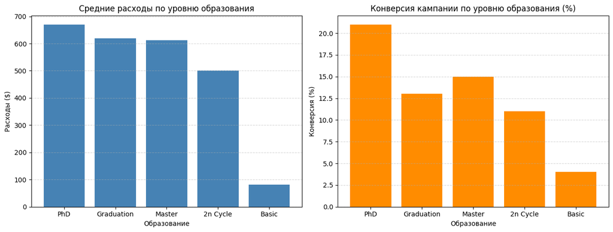

```python
t1_reset = t1.sort_values('Средние_расходы', ascending=False).reset_index()

fig, axes = plt.subplots(1, 2, figsize=(13, 5))

axes[0].bar(t1_reset['Education'], t1_reset['Средние_расходы'], color='steelblue')
axes[0].set_title('Средние расходы по уровню образования')
axes[0].set_xlabel('Образование')
axes[0].set_ylabel('Расходы ($)')
axes[0].grid(True, axis='y', linestyle='--', alpha=0.5)

axes[1].bar(t1_reset['Education'], t1_reset['Конверсия_pct'], color='darkorange')
axes[1].set_title('Конверсия кампании по уровню образования (%)')
axes[1].set_xlabel('Образование')
axes[1].set_ylabel('Конверсия (%)')
axes[1].grid(True, axis='y', linestyle='--', alpha=0.5)

plt.tight_layout()
plt.show()
```

```python
t2 = mkt.groupby('Age_group', observed=True).agg(
    Кол_клиентов    = ('ID',           'count'),
    Средний_доход   = ('Income',        'mean'),
    Средние_расходы = ('TotalSpend',    'mean'),
    Среднее_покупок = ('TotalPurchases','mean'),
    Конверсия_pct   = ('Response',      'mean')
).round(2)

t2['Конверсия_pct'] = (t2['Конверсия_pct'] * 100).round(1)

print('Сводная таблица 2: бизнес-показатели по возрастным группам')
t2
```

```
Сводная таблица 2: бизнес-показатели по возрастным группам
```

| Age_group | Кол_клиентов | Средний_доход | Средние_расходы | Среднее_покупок | Конверсия_pct |
| --- | --- | --- | --- | --- | --- |
| 18-30 | 10 | 58295.40 | 831.60 | 15.30 | 30.00 |
| 31-45 | 467 | 46461.25 | 558.33 | 13.05 | 18.00 |
| 46-60 | 1019 | 51136.62 | 548.64 | 14.47 | 14.00 |
| 60+ | 741 | 57279.54 | 711.11 | 16.56 | 15.00 |

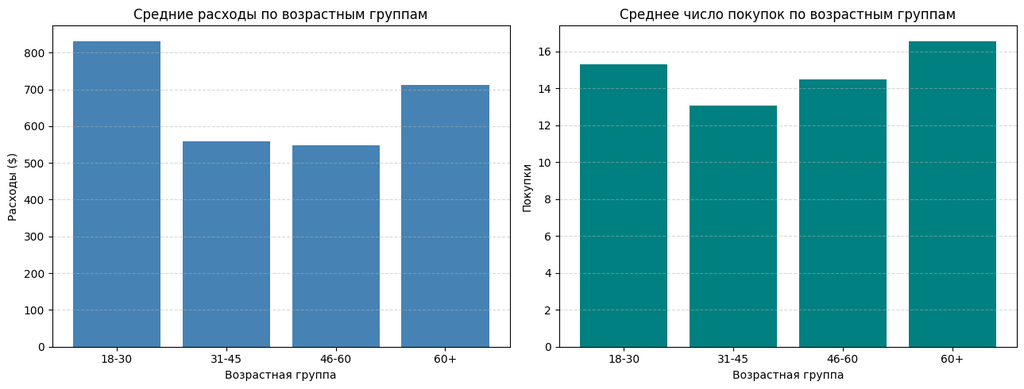

```python
t2_reset = t2.reset_index()

fig, axes = plt.subplots(1, 2, figsize=(13, 5))

axes[0].bar(t2_reset['Age_group'].astype(str), t2_reset['Средние_расходы'], color='steelblue')
axes[0].set_title('Средние расходы по возрастным группам')
axes[0].set_xlabel('Возрастная группа')
axes[0].set_ylabel('Расходы ($)')
axes[0].grid(True, axis='y', linestyle='--', alpha=0.5)

axes[1].bar(t2_reset['Age_group'].astype(str), t2_reset['Среднее_покупок'], color='teal')
axes[1].set_title('Среднее число покупок по возрастным группам')
axes[1].set_xlabel('Возрастная группа')
axes[1].set_ylabel('Покупки')
axes[1].grid(True, axis='y', linestyle='--', alpha=0.5)

plt.tight_layout()
plt.show()
```

```python
t3 = pd.pivot_table(
    mkt,
    index='Age_group',
    columns='Education',
    values='TotalSpend',
    aggfunc='mean'
).round(0)

print('Сводная таблица 3 (pivot_table): средние расходы по возрасту × образованию')
t3
```

```
Сводная таблица 3 (pivot_table): средние расходы по возрасту × образованию
```

| Education Age_group | 2n Cycle | Basic | Graduation | Master | PhD |
| --- | --- | --- | --- | --- | --- |
| 18-30 | 974.00 | 16.00 | 896.00 | NaN | NaN |
| 31-45 | 378.00 | 91.00 | 572.00 | 577.00 | 861.00 |
| 46-60 | 449.00 | 60.00 | 567.00 | 532.00 | 594.00 |
| 60+ | 737.00 | 101.00 | 728.00 | 721.00 | 693.00 |

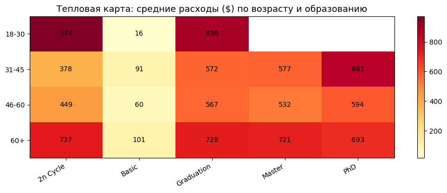

```python
fig, ax = plt.subplots(figsize=(10, 4))
im = ax.imshow(t3.values.astype(float), aspect='auto', cmap='YlOrRd')
ax.set_xticks(range(len(t3.columns)))
ax.set_yticks(range(len(t3.index)))
ax.set_xticklabels(t3.columns, rotation=30, ha='right')
ax.set_yticklabels(t3.index)

for i in range(len(t3.index)):
    for j in range(len(t3.columns)):
        val = t3.values[i, j]
        if not np.isnan(val):
            ax.text(j, i, f'{val:.0f}', ha='center', va='center', fontsize=10)

plt.colorbar(im, ax=ax)
ax.set_title('Тепловая карта: средние расходы ($) по возрасту и образованию', fontsize=13)
plt.tight_layout()
plt.show()
```

```python
t4 = pd.pivot_table(
    mkt,
    index='Marital_Status',
    columns='Age_group',
    values='TotalSpend',
    aggfunc='mean'
).round(0)

print('Сводная таблица 4 (pivot_table): средние расходы по семейному положению × возрасту')
t4
```

```
Сводная таблица 4 (pivot_table): средние расходы по семейному положению × возрасту
```

| Age_group Marital_Status | 18-30 | 31-45 | 46-60 | 60+ |
| --- | --- | --- | --- | --- |
| Absurd | NaN | 1216.00 | NaN | 1169.00 |
| Alone | NaN | 89.00 | 49.00 | 632.00 |
| Divorced | NaN | 597.00 | 580.00 | 663.00 |
| Married | 69.00 | 514.00 | 546.00 | 727.00 |
| Single | 966.00 | 584.00 | 531.00 | 731.00 |
| Together | 1191.00 | 590.00 | 548.00 | 677.00 |
| Widow | NaN | NaN | 607.00 | 799.00 |
| YOLO | NaN | NaN | 424.00 | NaN |

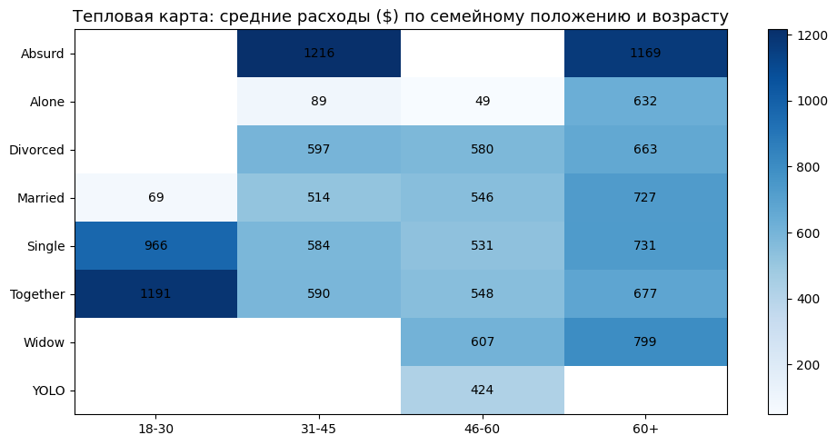

```python
fig, ax = plt.subplots(figsize=(10, 5))
im = ax.imshow(t4.values.astype(float), aspect='auto', cmap='Blues')
ax.set_xticks(range(len(t4.columns)))
ax.set_yticks(range(len(t4.index)))
ax.set_xticklabels(t4.columns)
ax.set_yticklabels(t4.index)

for i in range(len(t4.index)):
    for j in range(len(t4.columns)):
        val = t4.values[i, j]
        if not np.isnan(val):
            ax.text(j, i, f'{val:.0f}', ha='center', va='center', fontsize=10)

plt.colorbar(im, ax=ax)
ax.set_title('Тепловая карта: средние расходы ($) по семейному положению и возрасту', fontsize=13)
plt.tight_layout()
plt.show()
```

### 2.3 Сводные таблицы по товарным категориям

Выясним, на какие категории товаров клиенты тратят больше всего, и как расходы по категориям зависят от сегмента клиента.

```python
category_map = {
    'Вино':    'MntWines',
    'Мясо':    'MntMeatProducts',
    'Золото':  'MntGoldProds',
    'Рыба':    'MntFishProducts',
    'Сладкое': 'MntSweetProducts',
    'Фрукты':  'MntFruits'
}

t5 = pd.DataFrame({
    'Категория': list(category_map.keys()),
    'Сумма':     [mkt[c].sum()         for c in category_map.values()],
    'Среднее':   [round(mkt[c].mean(), 2) for c in category_map.values()],
    'Максимум':  [mkt[c].max()         for c in category_map.values()]
}).sort_values('Сумма', ascending=False).reset_index(drop=True)

t5['Доля (%)'] = (t5['Сумма'] / t5['Сумма'].sum() * 100).round(1)

print('Сводная таблица 5: расходы по товарным категориям')
t5
```

```
Сводная таблица 5: расходы по товарным категориям
```

|  | Категория | Сумма | Среднее | Максимум | Доля (%) |
| --- | --- | --- | --- | --- | --- |
| 0 | Вино | 680038 | 304.00 | 1493 | 50.20 |
| 1 | Мясо | 373393 | 166.92 | 1725 | 27.60 |
| 2 | Золото | 98358 | 43.97 | 362 | 7.30 |
| 3 | Рыба | 83939 | 37.52 | 259 | 6.20 |
| 4 | Сладкое | 60553 | 27.07 | 263 | 4.50 |
| 5 | Фрукты | 58767 | 26.27 | 199 | 4.30 |

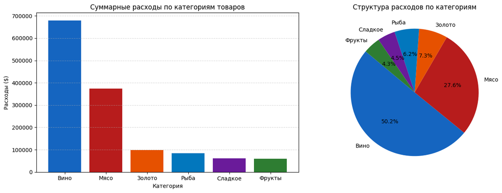

```python
colors = ['#1565C0','#B71C1C','#E65100','#0277BD','#6A1B9A','#2E7D32']

fig, axes = plt.subplots(1, 2, figsize=(14, 5))

axes[0].bar(t5['Категория'], t5['Сумма'], color=colors)
axes[0].set_title('Суммарные расходы по категориям товаров')
axes[0].set_xlabel('Категория')
axes[0].set_ylabel('Расходы ($)')
axes[0].grid(True, axis='y', linestyle='--', alpha=0.5)

axes[1].pie(t5['Сумма'], labels=t5['Категория'], autopct='%1.1f%%',
            startangle=140, colors=colors)
axes[1].set_title('Структура расходов по категориям')

plt.tight_layout()
plt.show()
```

```python
t6 = pd.pivot_table(
    mkt,
    index='spend_segment',
    values=list(category_map.values()),
    aggfunc='mean'
).rename(columns={v: k for k, v in category_map.items()}).round(1)

print('Сводная таблица 6 (pivot_table): средние расходы по категориям × сегмент клиента')
t6
```

```
Сводная таблица 6 (pivot_table): средние расходы по категориям × сегмент клиента
```

| spend_segment | Рыба | Фрукты | Золото | Мясо | Сладкое | Вино |
| --- | --- | --- | --- | --- | --- | --- |
| Низкий (<100) | 4.50 | 3.00 | 9.10 | 11.60 | 3.10 | 17.30 |
| Средний (100-500) | 16.50 | 11.20 | 34.90 | 58.70 | 11.50 | 142.10 |
| Высокий (500-1000) | 49.20 | 35.00 | 65.40 | 172.90 | 36.60 | 402.20 |
| Премиум (>1000) | 87.70 | 61.50 | 79.30 | 442.70 | 63.00 | 722.80 |

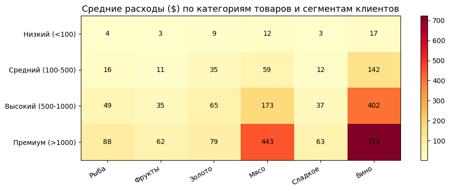

```python
fig, ax = plt.subplots(figsize=(10, 4))
im = ax.imshow(t6.values.astype(float), aspect='auto', cmap='YlOrRd')
ax.set_xticks(range(len(t6.columns)))
ax.set_yticks(range(len(t6.index)))
ax.set_xticklabels(t6.columns, rotation=30, ha='right')
ax.set_yticklabels(t6.index)

for i in range(len(t6.index)):
    for j in range(len(t6.columns)):
        ax.text(j, i, f"{t6.values[i,j]:.0f}", ha='center', va='center', fontsize=10)

plt.colorbar(im, ax=ax)
ax.set_title('Средние расходы ($) по категориям товаров и сегментам клиентов', fontsize=13)
plt.tight_layout()
plt.show()
```

```python
t7 = pd.pivot_table(
    mkt,
    index='Education',
    values=list(category_map.values()),
    aggfunc='mean'
).rename(columns={v: k for k, v in category_map.items()}).round(1)

print('Сводная таблица 7 (pivot_table): средние расходы по категориям × образование')
t7
```

```
Сводная таблица 7 (pivot_table): средние расходы по категориям × образование
```

| Education | Рыба | Фрукты | Золото | Мясо | Сладкое | Вино |
| --- | --- | --- | --- | --- | --- | --- |
| 2n Cycle | 47.90 | 29.20 | 46.70 | 142.60 | 34.60 | 200.00 |
| Basic | 17.10 | 11.10 | 22.80 | 11.40 | 12.10 | 7.20 |
| Graduation | 43.10 | 30.80 | 50.80 | 179.50 | 31.40 | 284.30 |
| Master | 32.10 | 21.70 | 40.40 | 163.40 | 21.20 | 333.10 |
| PhD | 26.60 | 19.80 | 31.90 | 167.80 | 20.10 | 403.80 |

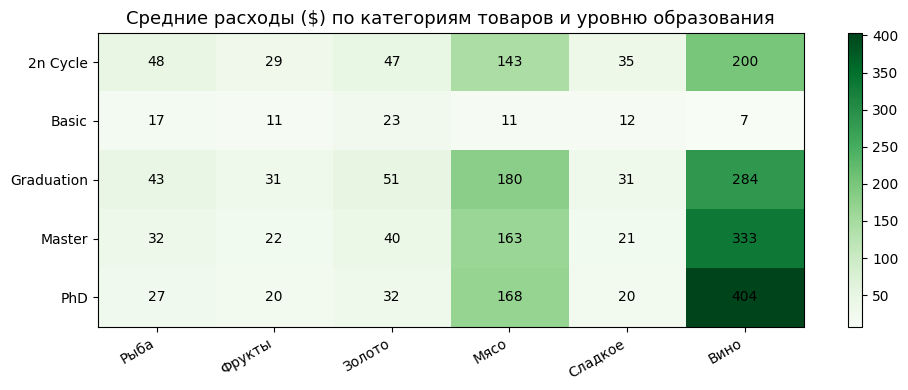

```python
fig, ax = plt.subplots(figsize=(10, 4))
im = ax.imshow(t7.values.astype(float), aspect='auto', cmap='Greens')
ax.set_xticks(range(len(t7.columns)))
ax.set_yticks(range(len(t7.index)))
ax.set_xticklabels(t7.columns, rotation=30, ha='right')
ax.set_yticklabels(t7.index)

for i in range(len(t7.index)):
    for j in range(len(t7.columns)):
        ax.text(j, i, f"{t7.values[i,j]:.0f}", ha='center', va='center', fontsize=10)

plt.colorbar(im, ax=ax)
ax.set_title('Средние расходы ($) по категориям товаров и уровню образования', fontsize=13)
plt.tight_layout()
plt.show()
```

### 2.4 Сводные таблицы по маркетинговым каналам и кампаниям

Определим, какие каналы продаж наиболее активны и как эффективность маркетинговых кампаний зависит от сегмента клиента.

```python
channel_map = {
    'Магазин': 'NumStorePurchases',
    'Веб':     'NumWebPurchases',
    'Каталог': 'NumCatalogPurchases',
    'Сделки':  'NumDealsPurchases'
}

t8 = pd.DataFrame({
    'Канал':                  list(channel_map.keys()),
    'Всего_покупок':          [mkt[c].sum()          for c in channel_map.values()],
    'Среднее_покупок':        [round(mkt[c].mean(),2)for c in channel_map.values()],
    'Корреляция_с_расходами': [round(mkt[c].corr(mkt['TotalSpend']),3) for c in channel_map.values()]
}).sort_values('Всего_покупок', ascending=False).reset_index(drop=True)

t8['Доля (%)'] = (t8['Всего_покупок'] / t8['Всего_покупок'].sum() * 100).round(1)

print('Сводная таблица 8: покупки по каналам продаж')
t8
```

```
Сводная таблица 8: покупки по каналам продаж
```

|  | Канал | Всего_покупок | Среднее_покупок | Корреляция_с_расходами | Доля (%) |
| --- | --- | --- | --- | --- | --- |
| 0 | Магазин | 12962 | 5.79 | 0.68 | 39.00 |
| 1 | Веб | 9143 | 4.09 | 0.52 | 27.50 |
| 2 | Каталог | 5956 | 2.66 | 0.78 | 17.90 |
| 3 | Сделки | 5205 | 2.33 | -0.07 | 15.60 |

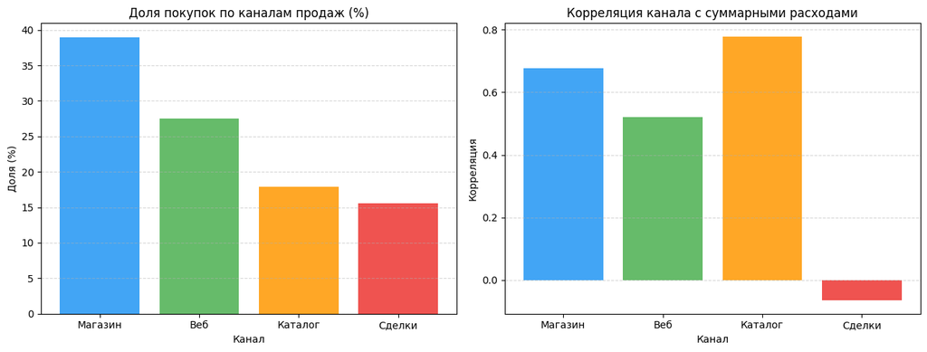

```python
fig, axes = plt.subplots(1, 2, figsize=(13, 5))

axes[0].bar(t8['Канал'], t8['Доля (%)'],
            color=['#42A5F5','#66BB6A','#FFA726','#EF5350'])
axes[0].set_title('Доля покупок по каналам продаж (%)')
axes[0].set_xlabel('Канал')
axes[0].set_ylabel('Доля (%)')
axes[0].grid(True, axis='y', linestyle='--', alpha=0.5)

axes[1].bar(t8['Канал'], t8['Корреляция_с_расходами'],
            color=['#42A5F5','#66BB6A','#FFA726','#EF5350'])
axes[1].set_title('Корреляция канала с суммарными расходами')
axes[1].set_xlabel('Канал')
axes[1].set_ylabel('Корреляция')
axes[1].grid(True, axis='y', linestyle='--', alpha=0.5)

plt.tight_layout()
plt.show()
```

```python
t9 = pd.pivot_table(
    mkt,
    index='Cohort',
    values=list(channel_map.values()),
    aggfunc='mean'
).rename(columns={v: k for k, v in channel_map.items()}).round(1)

print('Сводная таблица 9 (pivot_table): среднее число покупок по каналам × когорта регистрации')
t9
```

```
Сводная таблица 9 (pivot_table): среднее число покупок по каналам × когорта регистрации
```

| Cohort | Каталог | Сделки | Магазин | Веб |
| --- | --- | --- | --- | --- |
| 2012Q3 | 3.30 | 3.10 | 6.40 | 4.90 |
| 2012Q4 | 2.80 | 2.80 | 6.00 | 4.60 |
| 2013Q1 | 2.80 | 2.80 | 6.20 | 4.80 |
| 2013Q2 | 3.00 | 2.30 | 5.80 | 4.10 |
| 2013Q3 | 2.30 | 2.10 | 5.60 | 3.80 |
| 2013Q4 | 2.80 | 2.00 | 5.90 | 3.90 |
| 2014Q1 | 2.30 | 1.90 | 5.40 | 3.30 |
| 2014Q2 | 2.30 | 1.90 | 5.10 | 3.40 |

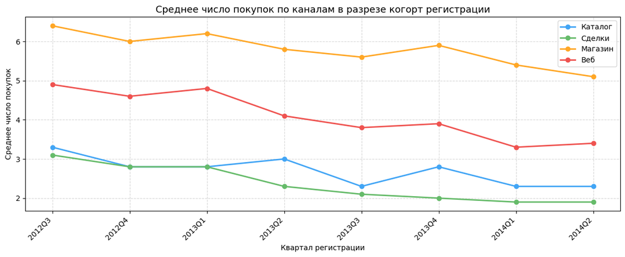

```python
fig, ax = plt.subplots(figsize=(12, 5))
colors_ch = ['#42A5F5','#66BB6A','#FFA726','#EF5350']
for col, color in zip(t9.columns, colors_ch):
    ax.plot(t9.index, t9[col], marker='o', linewidth=2, label=col, color=color)

ax.set_title('Среднее число покупок по каналам в разрезе когорт регистрации', fontsize=13)
ax.set_xlabel('Квартал регистрации')
ax.set_ylabel('Среднее число покупок')
ax.legend()
ax.grid(True, linestyle='--', alpha=0.5)
plt.xticks(rotation=45, ha='right')
plt.tight_layout()
plt.show()
```

```python
cmp_cols_all = ['AcceptedCmp1','AcceptedCmp2','AcceptedCmp3',
                'AcceptedCmp4','AcceptedCmp5','Response']
labels_cmp = ['Кампания 1','Кампания 2','Кампания 3','Кампания 4','Кампания 5','Последняя']

t10 = pd.DataFrame({
    'Кампания':    labels_cmp,
    'Принявших':   [mkt[c].sum()                    for c in cmp_cols_all],
    'Процент (%)': [round(mkt[c].mean() * 100, 1)   for c in cmp_cols_all]
})

print('Сводная таблица 10: принятие маркетинговых кампаний')
t10
```

```
Сводная таблица 10: принятие маркетинговых кампаний
```

|  | Кампания | Принявших | Процент (%) |
| --- | --- | --- | --- |
| 0 | Кампания 1 | 144 | 6.40 |
| 1 | Кампания 2 | 30 | 1.30 |
| 2 | Кампания 3 | 163 | 7.30 |
| 3 | Кампания 4 | 167 | 7.50 |
| 4 | Кампания 5 | 162 | 7.20 |
| 5 | Последняя | 334 | 14.90 |

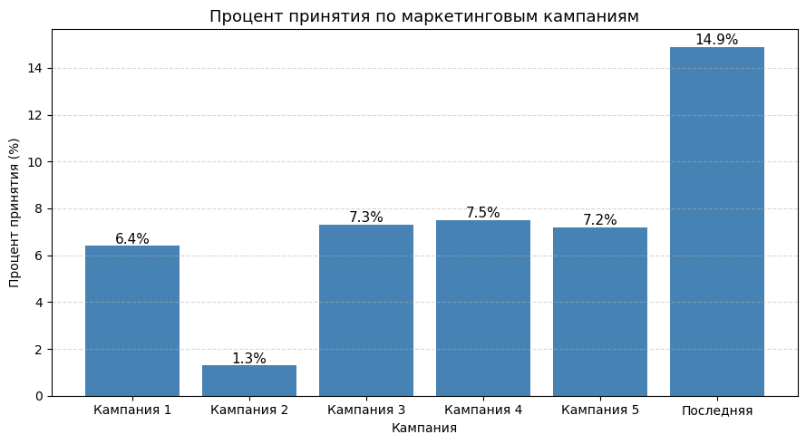

```python
fig, ax = plt.subplots(figsize=(9, 5))
ax.bar(t10['Кампания'], t10['Процент (%)'], color='steelblue')
ax.set_title('Процент принятия по маркетинговым кампаниям', fontsize=13)
ax.set_xlabel('Кампания')
ax.set_ylabel('Процент принятия (%)')
ax.grid(True, axis='y', linestyle='--', alpha=0.5)
for i, v in enumerate(t10['Процент (%)']):
    ax.text(i, v + 0.1, f'{v}%', ha='center', fontsize=11)
plt.tight_layout()
plt.show()
```

```python
t11 = pd.pivot_table(
    mkt,
    index='spend_segment',
    columns='Education',
    values='Response',
    aggfunc='mean'
).round(3) * 100

print('Сводная таблица 11 (pivot_table): конверсия (%) — сегмент расходов × образование')
t11.round(1)
```

```
Сводная таблица 11 (pivot_table): конверсия (%) — сегмент расходов × образование
```

| Education spend_segment | 2n Cycle | Basic | Graduation | Master | PhD |
| --- | --- | --- | --- | --- | --- |
| Низкий (<100) | 7.10 | 2.30 | 6.60 | 8.60 | 9.20 |
| Средний (100-500) | 5.60 | 11.10 | 13.40 | 13.80 | 16.20 |
| Высокий (500-1000) | 7.90 | 0.00 | 6.40 | 6.20 | 23.50 |
| Премиум (>1000) | 25.60 | NaN | 25.90 | 31.50 | 32.70 |

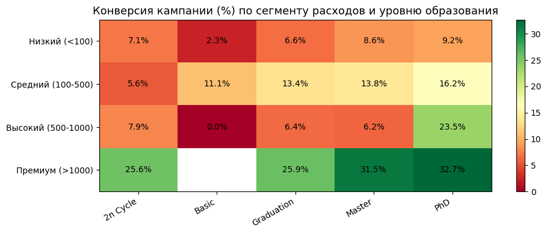

```python
fig, ax = plt.subplots(figsize=(10, 4))
im = ax.imshow(t11.values.astype(float), aspect='auto', cmap='RdYlGn')
ax.set_xticks(range(len(t11.columns)))
ax.set_yticks(range(len(t11.index)))
ax.set_xticklabels(t11.columns, rotation=30, ha='right')
ax.set_yticklabels(t11.index)

for i in range(len(t11.index)):
    for j in range(len(t11.columns)):
        val = t11.values[i, j]
        if not np.isnan(val):
            ax.text(j, i, f'{val:.1f}%', ha='center', va='center', fontsize=10)

plt.colorbar(im, ax=ax)
ax.set_title('Конверсия кампании (%) по сегменту расходов и уровню образования', fontsize=13)
plt.tight_layout()
plt.show()
```

### 2.5 Сводные таблицы: когортный анализ и LTV

Проведём когортный анализ: сгруппируем клиентов по кварталу регистрации и посмотрим, как меняется их ценность со временем.

```python
t12 = mkt.groupby('Cohort').agg(
    Кол_клиентов    = ('ID',           'count'),
    Средние_расходы = ('TotalSpend',    'mean'),
    Среднее_покупок = ('TotalPurchases','mean'),
    Принявших_pct   = ('AcceptedAny',   'mean')
).round(2).reset_index()

t12['Принявших_pct'] = (t12['Принявших_pct'] * 100).round(1)

print('Сводная таблица 12: LTV и активность по когортам регистрации')
t12
```

```
Сводная таблица 12: LTV и активность по когортам регистрации
```

|  | Cohort | Кол_клиентов | Средние_расходы | Среднее_покупок | Принявших_pct |
| --- | --- | --- | --- | --- | --- |
| 0 | 2012Q3 | 219 | 816.87 | 17.73 | 19.00 |
| 1 | 2012Q4 | 275 | 688.63 | 16.13 | 23.00 |
| 2 | 2013Q1 | 309 | 671.69 | 16.59 | 22.00 |
| 3 | 2013Q2 | 284 | 631.42 | 15.17 | 17.00 |
| 4 | 2013Q3 | 295 | 511.50 | 13.73 | 18.00 |
| 5 | 2013Q4 | 299 | 587.76 | 14.52 | 19.00 |
| 6 | 2014Q1 | 277 | 502.34 | 12.94 | 25.00 |
| 7 | 2014Q2 | 279 | 480.73 | 12.67 | 22.00 |

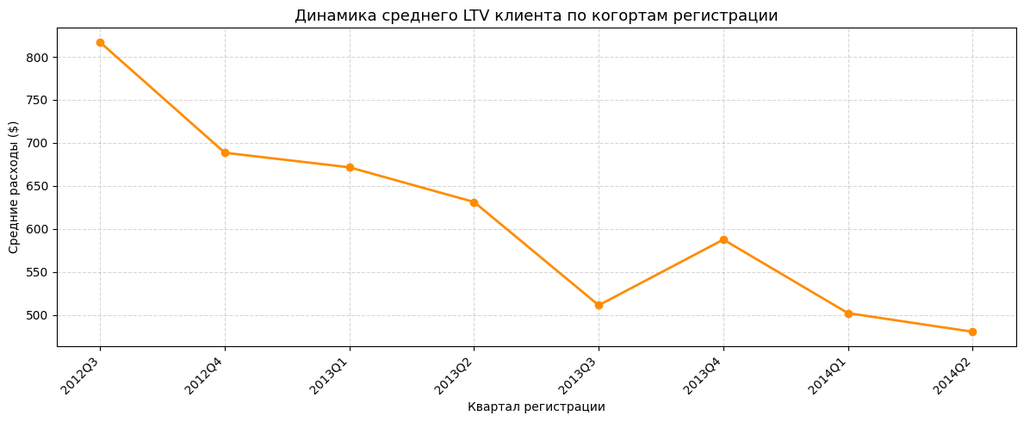

```python
fig, ax = plt.subplots(figsize=(12, 5))
ax.plot(t12['Cohort'], t12['Средние_расходы'],
        marker='o', linewidth=2, color='darkorange')
ax.set_title('Динамика среднего LTV клиента по когортам регистрации', fontsize=13)
ax.set_xlabel('Квартал регистрации')
ax.set_ylabel('Средние расходы ($)')
ax.grid(True, linestyle='--', alpha=0.5)
plt.xticks(rotation=45, ha='right')
plt.tight_layout()
plt.show()
```

```python
ltv = round(mkt['TotalSpend'].mean(), 2)
cac = round(mkt['Z_CostContact'].mean(), 2)
roi = round((ltv - cac) / cac * 100, 1)
conv = round(mkt['Response'].mean() * 100, 1)
repeat = round((mkt['TotalPurchases'] > 5).mean() * 100, 1)

metrics = pd.DataFrame({
    'Метрика': ['LTV (средние расходы на клиента)',
                'CAC (стоимость контакта)',
                'ROI',
                'Конверсия последней кампании',
                'Доля клиентов с >5 покупками'],
    'Значение': [f'${ltv}', f'${cac}', f'{roi}%', f'{conv}%', f'{repeat}%']
})

print('Ключевые бизнес-метрики:')
metrics
```

```
Ключевые бизнес-метрики:
```

|  | Метрика | Значение |
| --- | --- | --- |
| 0 | LTV (средние расходы на клиента) | $605.74 |
| 1 | CAC (стоимость контакта) | $3.0 |
| 2 | ROI | 20091.3% |
| 3 | Конверсия последней кампании | 14.9% |
| 4 | Доля клиентов с >5 покупками | 87.3% |

### 2.6 Сводные таблицы по географии и демографии

```python
t13 = (olist_clean.groupby('customer_state')
                  .agg(Кол_клиентов=('customer_unique_id','count'),
                       Кол_городов  =('customer_city',      'nunique'))
                  .sort_values('Кол_клиентов', ascending=False)
                  .reset_index())

print('Сводная таблица 13: клиенты Olist по штатам (топ-10)')
t13.head(10)
```

```
Сводная таблица 13: клиенты Olist по штатам (топ-10)
```

|  | customer_state | Кол_клиентов | Кол_городов |
| --- | --- | --- | --- |
| 0 | SP | 40295 | 629 |
| 1 | RJ | 12377 | 149 |
| 2 | MG | 11255 | 745 |
| 3 | RS | 5277 | 379 |
| 4 | PR | 4882 | 364 |
| 5 | SC | 3529 | 240 |
| 6 | BA | 3276 | 353 |
| 7 | DF | 2073 | 6 |
| 8 | ES | 1963 | 95 |
| 9 | GO | 1951 | 177 |

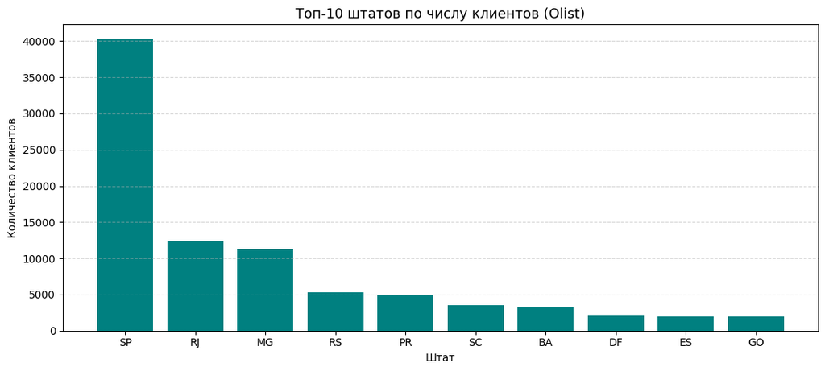

```python
fig, ax = plt.subplots(figsize=(11, 5))
ax.bar(t13.head(10)['customer_state'], t13.head(10)['Кол_клиентов'], color='teal')
ax.set_title('Топ-10 штатов по числу клиентов (Olist)', fontsize=13)
ax.set_xlabel('Штат')
ax.set_ylabel('Количество клиентов')
ax.grid(True, axis='y', linestyle='--', alpha=0.5)
plt.tight_layout()
plt.show()
```

```python
t14 = pd.pivot_table(
    seg,
    index='Gender',
    columns='Spending_Score',
    values='ID',
    aggfunc='count'
).fillna(0).astype(int)

print('Сводная таблица 14 (pivot_table): число клиентов — пол × уровень расходов')
t14
```

```
Сводная таблица 14 (pivot_table): число клиентов — пол × уровень расходов
```

| Spending_Score Gender | Average | High | Low |
| --- | --- | --- | --- |
| Female | 272 | 159 | 772 |
| Male | 353 | 227 | 844 |

```python
t15 = pd.pivot_table(
    seg,
    index='Profession',
    columns='Spending_Score',
    values='ID',
    aggfunc='count'
).fillna(0).astype(int)

print('Сводная таблица 15 (pivot_table): число клиентов — профессия × уровень расходов')
t15
```

```
Сводная таблица 15 (pivot_table): число клиентов — профессия × уровень расходов
```

| Spending_Score Profession | Average | High | Low |
| --- | --- | --- | --- |
| Artist | 311 | 80 | 449 |
| Doctor | 69 | 11 | 162 |
| Engineer | 79 | 16 | 141 |
| Entertainment | 101 | 16 | 184 |
| Executive | 20 | 116 | 40 |
| Healthcare | 12 | 10 | 396 |
| Homemaker | 18 | 8 | 56 |
| Lawyer | 6 | 117 | 98 |
| Marketing | 9 | 12 | 90 |

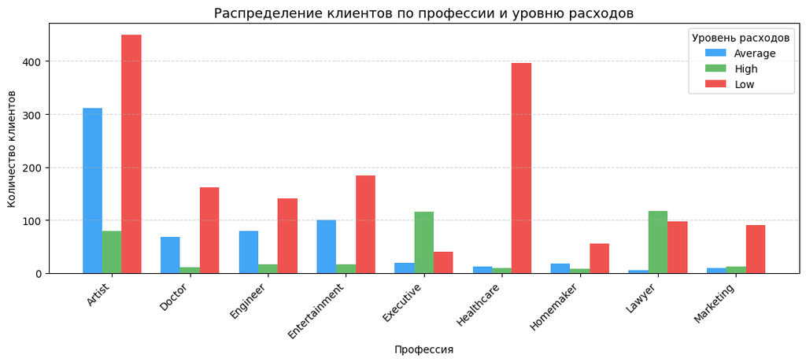

```python
fig, ax = plt.subplots(figsize=(11, 5))
x = range(len(t15.index))
width = 0.25
colors_sp = ['#42A5F5','#66BB6A','#EF5350']
for i, col in enumerate(t15.columns):
    ax.bar([xi + i*width for xi in x], t15[col], width=width, label=col, color=colors_sp[i])

ax.set_title('Распределение клиентов по профессии и уровню расходов', fontsize=13)
ax.set_xlabel('Профессия')
ax.set_ylabel('Количество клиентов')
ax.set_xticks([xi + width for xi in x])
ax.set_xticklabels(t15.index, rotation=45, ha='right')
ax.legend(title='Уровень расходов')
ax.grid(True, axis='y', linestyle='--', alpha=0.5)
plt.tight_layout()
plt.show()
```

## Раздел 3: Выводы

По результатам анализа бизнес-показателей маркетплейса на основе построения сводных таблиц были получены следующие выводы:

Наибольшие средние расходы демонстрируют клиенты с образованием PhD (670) и Graduation (620), что выше среднего по базе (606). Конверсия также наибольшая у PhD - 21%, что почти в пять раз выше, чем у клиентов с базовым образованием (4%). По возрасту лидируют группы 18–30 лет (832) и 60+ (711), при этом группа 18–30 показывает наибольшую конверсию (30%). Сводная таблица «возраст × образование» показала, что молодые клиенты с уровнем 2nd Cycle (магистратура) тратят больше сверстников с другим образованием (974 vs 896). Клиенты в статусе «Together» и «Single» в молодом возрасте тратят больше всего (1191 и 966 соответственно).

Категория «Вино» составляет 50,2% всех расходов, «Мясо» - 27,6%. Вместе они формируют около 78% выручки. Сводная таблица «категория × сегмент» выявила ключевую закономерность: у премиум-клиентов (более 1000) расходы на вино (722,8) в 41,8 раза выше, чем у клиентов сегмента менее 100 (17,3). Клиенты с PhD тратят на вино в среднем 403,8 - это наибольший показатель среди всех уровней образования.

Канал «Магазин» лидирует по числу покупок (39%), однако «Каталог» имеет наибольшую корреляцию с суммарными расходами (0,78), через него приходят наиболее ценные клиенты. Канал «Сделки» показывает отрицательную корреляцию (-0,07): скидочные покупатели тратят меньше остальных. Сводная таблица по когортам показала снижение активности по каждому каналу у более поздних клиентов. Кампании 3, 4 и 5 наиболее эффективны (7,2–7,5%), кампания 2 - наименее (1,3%). Сводная таблица «конверсия × сегмент × образование» подтвердила, что PhD-клиенты из премиум-сегмента конвертируются лучше всех - 32,7%.

Штат SP (São Paulo) концентрирует более 40% клиентской базы Olist при 629 городах. По сводной таблице «профессия × уровень расходов» видно, что наибольшую долю клиентов с высокими расходами имеют профессии Lawyer (117 из 221) и Executive (116 из 176). Healthcare напротив доминирует в сегменте низких расходов (Low=396 при High=10).

Рекомендуемые меры:

- направить маркетинговый бюджет на сегмент PhD/Graduation и возрастные группы 18–30 и 60+;
- увеличить инвестиции в каталожный канал (корреляция 0,78) и сократить бюджет на канал «Сделки» (-0,07);
- масштабировать механику кампаний 3, 4 и 5;
- разработать кросс-продажные предложения «Вино + Мясо» для премиум-сегмента;
- проработать стратегию удержания ранних когорт, так как LTV снижается на 41% за два года.

Три датасета не имеют прямой связи на уровне пользователей, результаты основаны на аналитических допущениях. CAC рассчитан по упрощённой стоимости контакта из датасета.